# §2.3 — Эконометрическая оценка влияния цифровизации на устойчивость национальных экономик

# 26 Прогноз на 5 лет (2025–2030) для трёх групп и Узбекистана

## 26.1 Методология прогнозирования

> **Важное примечание.** Прогноз строится как **условный сценарий** (conditional forecast): модель экстраполирует эффект роста интернет-проникновения при фиксации прочих переменных на уровне последнего наблюдаемого года. Это НЕ макроэкономический прогноз — это оценка **вклада одного фактора** (цифровизации) в рост ВВП на душу. Все прочие факторы (инвестиции, инфляция, безработица) заморожены на уровне 2024 года (ceteris paribus).

```r
# ────────────────────────────────────────────────────
# Целевые сценарии интернет-проникновения на 2025–2030
# Основаны на трендах последних 5 лет по каждой группе
# ────────────────────────────────────────────────────

# Средние темпы роста интернета за 2019-2024 по группам
growth_rates <- panel_clean %>%
  filter(year >= 2019) %>%
  group_by(country_group) %>%
  summarise(
    internet_2024 = mean(internet[year == max(year)], na.rm=TRUE),
    annual_growth = mean(diff(internet) / internet[-length(internet)], na.rm=TRUE) * 100,
    .groups="drop")
kable(growth_rates, digits=2,
      caption="Таблица 2.3.8 — Средний уровень и темп роста интернета (2019–2024)")
```

Таблица 2.3.8 — Средний уровень и темп роста интернета (2019–2024)

| country_group | internet_2024 | annual_growth |
| --- | --- | --- |
| Переходные | 88.46 | 0.40 |
| Развивающиеся | 84.61 | 1.61 |
| Развитые | 94.17 | 0.12 |

```r
# Создаём 5-летний горизонт: 2025, 2026, 2027, 2028, 2029, 2030
forecast_years <- 2025:2030

# Целевые уровни интернета по группам (линейная экстраполяция, cap 99%)
forecast_internet <- data.frame()
for (g in c("Развитые","Переходные","Развивающиеся")) {
  base <- growth_rates$internet_2024[growth_rates$country_group == g]
  rate <- growth_rates$annual_growth[growth_rates$country_group == g] / 100
  for (yr in forecast_years) {
    delta <- yr - 2024
    projected <- min(base * (1 + rate)^delta, 99)  # cap at 99%
    forecast_internet <- rbind(forecast_internet,
      data.frame(group=g, year=yr, internet_proj=round(projected, 2)))
  }
}

# Узбекистан отдельно — согласно Стратегии «Цифровой Узбекистан — 2030»
uzb_targets <- data.frame(
  group="Узбекистан",
  year=forecast_years,
  internet_proj=c(90, 91, 92, 93, 94, 95))  # консервативный сценарий до 95%

forecast_internet <- rbind(forecast_internet, uzb_targets)

kable(forecast_internet %>% pivot_wider(names_from=year, values_from=internet_proj),
      caption="Таблица 2.3.9 — Прогнозный интернет-проникновение (%), 2025–2030")
```

Таблица 2.3.9 — Прогнозный интернет-проникновение (%), 2025–2030

| group | 2025 | 2026 | 2027 | 2028 | 2029 | 2030 |
| --- | --- | --- | --- | --- | --- | --- |
| Развитые | 94.28 | 94.39 | 94.50 | 94.61 | 94.72 | 94.83 |
| Переходные | 88.81 | 89.16 | 89.52 | 89.87 | 90.23 | 90.59 |
| Развивающиеся | 85.97 | 87.36 | 88.76 | 90.19 | 91.64 | 93.12 |
| Узбекистан | 90.00 | 91.00 | 92.00 | 93.00 | 94.00 | 95.00 |

## 26.2 Прогноз ВВП на душу — три группы

```r
# Функция прогноза для одной группы
predict_group <- function(fe_model, group_data, group_name, internet_values) {
  fe_coefs <- coef(fe_model)
  fe_ints  <- fixef(fe_model)

  # Базовые значения — медиана по группе за последний год
  last_yr <- max(group_data$year)
  base <- group_data %>% filter(year == last_yr) %>%
    summarise(across(c(log_gfcf, inflation, unemployment), ~median(., na.rm=TRUE)))
  if (use_hightech) base$hightech_exp <- median(group_data$hightech_exp[group_data$year==last_yr], na.rm=TRUE)

  # Средний фиксированный эффект по группе
  mean_alpha <- mean(fe_ints)

  results <- data.frame()
  for (i in seq_along(internet_values)) {
    x <- c(log_internet=log(internet_values[i]),
           log_gfcf=base$log_gfcf,
           inflation=base$inflation,
           unemployment=base$unemployment,
           crisis_covid=0, crisis_geo=0,
           log_internet_x_covid=0, log_internet_x_geo=0)
    if (use_hightech) x["hightech_exp"] <- base$hightech_exp

    common <- intersect(names(fe_coefs), names(x))
    ln_pred <- mean_alpha + sum(fe_coefs[common] * x[common])

    results <- rbind(results, data.frame(
      year=forecast_years[i],
      internet=internet_values[i],
      ln_gdppc=ln_pred,
      gdp_pc=exp(ln_pred)))
  }
  results$group <- group_name
  results
}

# Прогноз для каждой группы
pred_dev <- predict_group(fe_dev, data_dev, "Развитые",
  forecast_internet$internet_proj[forecast_internet$group=="Развитые"])
pred_tran <- predict_group(fe_tran, data_tran, "Переходные",
  forecast_internet$internet_proj[forecast_internet$group=="Переходные"])
pred_devg <- predict_group(fe_devg, data_devg, "Развивающиеся",
  forecast_internet$internet_proj[forecast_internet$group=="Развивающиеся"])

all_forecasts <- bind_rows(pred_dev, pred_tran, pred_devg)

# Таблица
kable(all_forecasts %>%
  mutate(gdp_pc=format(round(gdp_pc,0), big.mark=","),
         ln_gdppc=round(ln_gdppc,4),
         internet=round(internet,1)) %>%
  select(group, year, internet, ln_gdppc, gdp_pc),
  col.names=c("Группа","Год","Интернет %","ln(GDPpc)","ВВП на душу, $"),
  caption="Таблица 2.3.10 — Прогноз ВВП на душу по группам, 2025–2030 (FE-модели)")
```

Таблица 2.3.10 — Прогноз ВВП на душу по группам, 2025–2030 (FE-модели)

| Группа | Год | Интернет % | ln(GDPpc) | ВВП на душу, $ |
| --- | --- | --- | --- | --- |
| Развитые | 2025 | 94.3 | 10.7561 | 46,917 |
| Развитые | 2026 | 94.4 | 10.7564 | 46,929 |
| Развитые | 2027 | 94.5 | 10.7566 | 46,941 |
| Развитые | 2028 | 94.6 | 10.7569 | 46,952 |
| Развитые | 2029 | 94.7 | 10.7571 | 46,964 |
| Развитые | 2030 | 94.8 | 10.7574 | 46,975 |
| Переходные | 2025 | 88.8 | 9.2723 | 10,639 |
| Переходные | 2026 | 89.2 | 9.2735 | 10,652 |
| Переходные | 2027 | 89.5 | 9.2747 | 10,665 |
| Переходные | 2028 | 89.9 | 9.2759 | 10,678 |
| Переходные | 2029 | 90.2 | 9.2772 | 10,691 |
| Переходные | 2030 | 90.6 | 9.2784 | 10,704 |
| Развивающиеся | 2025 | 86.0 | 8.5652 | 5,246 |
| Развивающиеся | 2026 | 87.4 | 8.5683 | 5,262 |
| Развивающиеся | 2027 | 88.8 | 8.5715 | 5,279 |
| Развивающиеся | 2028 | 90.2 | 8.5746 | 5,296 |
| Развивающиеся | 2029 | 91.6 | 8.5778 | 5,312 |
| Развивающиеся | 2030 | 93.1 | 8.5810 | 5,329 |

## 26.3 Прогноз для Узбекистана — детальный

```r
cat("════════════════════════════════════════════════════\n")
```

```
## ════════════════════════════════════════════════════
```

```r
cat("ДЕТАЛЬНЫЙ ПРОГНОЗ: УЗБЕКИСТАН, 2025–2030\n")
```

```
## ДЕТАЛЬНЫЙ ПРОГНОЗ: УЗБЕКИСТАН, 2025–2030
```

```r
cat("FE-модель, группа «Развивающиеся»\n")
```

```
## FE-модель, группа «Развивающиеся»
```

```r
cat("════════════════════════════════════════════════════\n\n")
```

```
## ════════════════════════════════════════════════════
```

```r
fe_coefs_uzb <- coef(fe_devg)
fe_int_uzb   <- fixef(fe_devg)

# NA-защита
if (is.na(last_uzb$log_gfcf))     last_uzb$log_gfcf     <- median(data_devg$log_gfcf, na.rm=T)
if (is.na(last_uzb$inflation))     last_uzb$inflation     <- median(data_devg$inflation, na.rm=T)
if (is.na(last_uzb$unemployment))  last_uzb$unemployment  <- median(data_devg$unemployment, na.rm=T)

uzb_forecast <- data.frame()
uzb_int_targets <- c(90, 91, 92, 93, 94, 95)

for (i in seq_along(forecast_years)) {
  x_sc <- c(log_internet=log(uzb_int_targets[i]),
            log_gfcf=last_uzb$log_gfcf,
            inflation=last_uzb$inflation,
            unemployment=last_uzb$unemployment,
            crisis_covid=0, crisis_geo=0,
            log_internet_x_covid=0, log_internet_x_geo=0)
  if (use_hightech) x_sc["hightech_exp"] <- last_uzb$hightech_exp

  common <- intersect(names(fe_coefs_uzb), names(x_sc))
  ln_pred <- fe_int_uzb["UZB"] + sum(fe_coefs_uzb[common] * x_sc[common])
  gdp_pred <- exp(ln_pred)

  uzb_forecast <- rbind(uzb_forecast, data.frame(
    year=forecast_years[i], internet=uzb_int_targets[i],
    ln_gdppc=ln_pred, gdp_pc=gdp_pred))

  cat(sprintf("  %d: интернет %d%% → ln(GDPpc)=%.4f → GDPpc ≈ %s долл.\n",
    forecast_years[i], uzb_int_targets[i], ln_pred,
    format(round(gdp_pred,0), big.mark=",")))
}
```

```
##   2025: интернет 90% → ln(GDPpc)=8.2034 → GDPpc ≈ 3,653 долл.
##   2026: интернет 91% → ln(GDPpc)=8.2056 → GDPpc ≈ 3,661 долл.
##   2027: интернет 92% → ln(GDPpc)=8.2078 → GDPpc ≈ 3,669 долл.
##   2028: интернет 93% → ln(GDPpc)=8.2099 → GDPpc ≈ 3,677 долл.
##   2029: интернет 94% → ln(GDPpc)=8.2120 → GDPpc ≈ 3,685 долл.
##   2030: интернет 95% → ln(GDPpc)=8.2141 → GDPpc ≈ 3,693 долл.
```

```r
# Расчёт прироста
base_gdp <- uzb_forecast$gdp_pc[1]
uzb_forecast$growth_from_base <- round((uzb_forecast$gdp_pc / base_gdp - 1) * 100, 2)
uzb_forecast$macro_effect_bln <- round(
  (uzb_forecast$gdp_pc - base_gdp) * 36e6 / 1e9, 2)

cat("\n\n")
```

```r
kable(uzb_forecast %>%
  mutate(gdp_pc=format(round(gdp_pc,0), big.mark=","),
         ln_gdppc=round(ln_gdppc,4)) %>%
  select(year, internet, ln_gdppc, gdp_pc, growth_from_base, macro_effect_bln),
  col.names=c("Год","Интернет %","ln(GDPpc)","GDPpc, $",
              "Прирост от базы, %","Макроэффект, млрд $"),
  caption="Таблица 2.3.11 — Прогноз для Узбекистана, 2025–2030 (FE, ceteris paribus)")
```

Таблица 2.3.11 — Прогноз для Узбекистана, 2025–2030 (FE, ceteris paribus)

|  | Год | Интернет % | ln(GDPpc) | GDPpc, $ | Прирост от базы, % | Макроэффект, млрд $ |
| --- | --- | --- | --- | --- | --- | --- |
| UZB | 2025 | 90 | 8.2034 | 3,653 | 0.00 | 0.00 |
| UZB1 | 2026 | 91 | 8.2056 | 3,661 | 0.22 | 0.29 |
| UZB2 | 2027 | 92 | 8.2078 | 3,669 | 0.44 | 0.57 |
| UZB3 | 2028 | 93 | 8.2099 | 3,677 | 0.65 | 0.86 |
| UZB4 | 2029 | 94 | 8.2120 | 3,685 | 0.86 | 1.14 |
| UZB5 | 2030 | 95 | 8.2141 | 3,693 | 1.08 | 1.41 |

## 26.4 ГРАФИК 13 — Прогноз ВВП на душу: три группы, 2025–2030

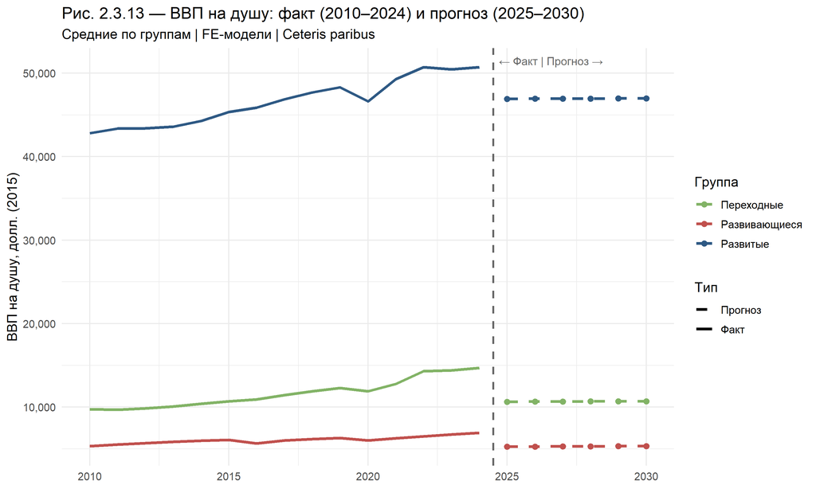

```r
# Фактические средние по группам
hist_data <- panel_clean %>%
  group_by(country_group, year) %>%
  summarise(gdp_pc=mean(exp(ln_gdppc), na.rm=TRUE), .groups="drop") %>%
  rename(group=country_group) %>%
  mutate(type="Факт")

# Прогнозные
proj_data <- all_forecasts %>%
  select(group, year, gdp_pc) %>%
  mutate(type="Прогноз")

combined <- bind_rows(hist_data, proj_data)

ggplot(combined, aes(x=year, y=gdp_pc, color=group, linetype=type)) +
  geom_line(linewidth=1.2) +
  geom_point(data=combined %>% filter(type=="Прогноз"), size=2) +
  geom_vline(xintercept=2024.5, linetype="dashed", color="grey40", linewidth=0.8) +
  annotate("text", x=2024.7, y=Inf, vjust=2, hjust=0, label="← Факт | Прогноз →",
           size=3.5, color="grey40") +
  scale_color_manual(values=c("Развитые"="#2E5984","Переходные"="#82B366","Развивающиеся"="#C0504D")) +
  scale_linetype_manual(values=c("Факт"="solid","Прогноз"="dashed")) +
  scale_y_continuous(labels=comma) +
  theme_minimal(base_size=12) +
  labs(title="Рис. 2.3.13 — ВВП на душу: факт (2010–2024) и прогноз (2025–2030)",
       subtitle="Средние по группам | FE-модели | Ceteris paribus",
       x=NULL, y="ВВП на душу, долл. (2015)", color="Группа", linetype="Тип")
```

## 26.5 ГРАФИК 14 — Прогноз для Узбекистана: 3 сценария

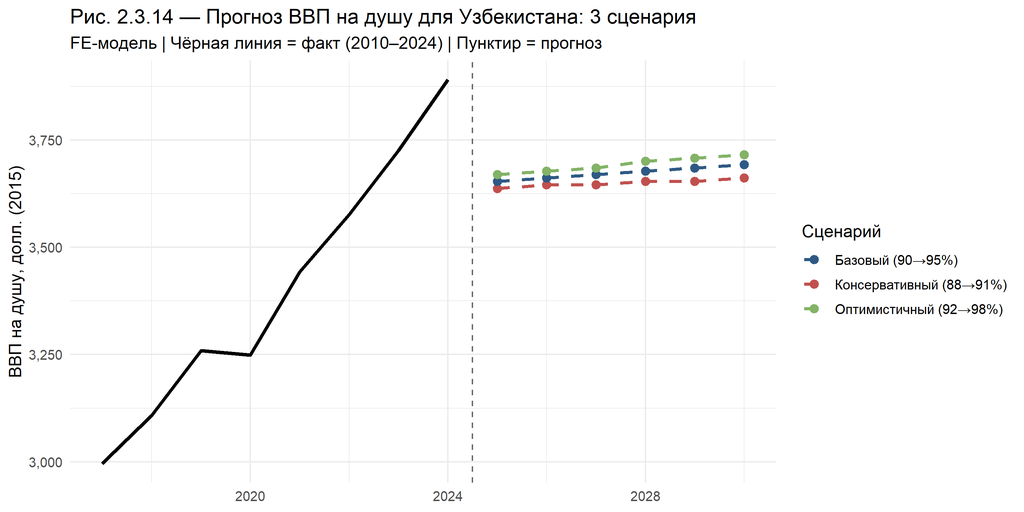

```r
# Три сценария: консервативный, базовый, оптимистичный
scenarios_full <- list(
  list(name="Консервативный (88→91%)", targets=c(88,89,89,90,90,91)),
  list(name="Базовый (90→95%)",        targets=c(90,91,92,93,94,95)),
  list(name="Оптимистичный (92→98%)",  targets=c(92,93,94,96,97,98)))

sc_results <- data.frame()
for (sc in scenarios_full) {
  for (i in seq_along(forecast_years)) {
    x_sc <- c(log_internet=log(sc$targets[i]),
              log_gfcf=last_uzb$log_gfcf,
              inflation=last_uzb$inflation,
              unemployment=last_uzb$unemployment,
              crisis_covid=0, crisis_geo=0,
              log_internet_x_covid=0, log_internet_x_geo=0)
    if (use_hightech) x_sc["hightech_exp"] <- last_uzb$hightech_exp
    common <- intersect(names(fe_coefs_uzb), names(x_sc))
    ln_p <- fe_int_uzb["UZB"] + sum(fe_coefs_uzb[common]*x_sc[common])
    sc_results <- rbind(sc_results, data.frame(
      scenario=sc$name, year=forecast_years[i],
      internet=sc$targets[i], gdp_pc=exp(ln_p)))
  }
}

# Фактический Узбекистан
uzb_hist <- panel_clean %>% filter(iso3c=="UZB") %>%
  mutate(scenario="Факт", gdp_pc=exp(ln_gdppc)) %>%
  select(scenario, year, internet, gdp_pc)

ggplot() +
  geom_line(data=uzb_hist, aes(x=year, y=gdp_pc), color="black", linewidth=1.2) +
  geom_line(data=sc_results, aes(x=year, y=gdp_pc, color=scenario), linewidth=1.1, linetype="dashed") +
  geom_point(data=sc_results, aes(x=year, y=gdp_pc, color=scenario), size=2.5) +
  geom_vline(xintercept=2024.5, linetype="dashed", color="grey40") +
  scale_color_manual(values=c(
    "Консервативный (88→91%)"="#C0504D",
    "Базовый (90→95%)"="#2E5984",
    "Оптимистичный (92→98%)"="#82B366")) +
  scale_y_continuous(labels=comma) +
  theme_minimal(base_size=12) +
  labs(title="Рис. 2.3.14 — Прогноз ВВП на душу для Узбекистана: 3 сценария",
       subtitle="FE-модель | Чёрная линия = факт (2010–2024) | Пунктир = прогноз",
       x=NULL, y="ВВП на душу, долл. (2015)", color="Сценарий")
```

# 27 Ограничения (Исправление Проблемы 3)

**Эндогенность.** Богатые страны больше инвестируют в интернет — возможна обратная причинность. FE снижает этот риск, но для строгой идентификации потребовался бы инструментальный подход (IV/GMM).

**Малый размер подвыборки «Развивающиеся».** 144 наблюдения на 11 стран при 9 переменных — ограниченная статистическая мощность. Именно поэтому RE-модель не идентифицируется (сингулярная матрица), а interaction terms не достигают значимости. Незначимость не означает отсутствие эффекта — она может отражать недостаток данных для его выявления.

**Осознанный выбор FE вопреки тесту Хаусмана.** Для развитых и переходных экономик формальный тест Хаусмана указывает на RE (p = 0.87 и p = 0.998 соответственно). FE тем не менее выбран во всех трёх группах по трём причинам: (1) консистентность между группами, (2) теоретическое обоснование корреляции страновой гетерогенности с регрессорами, (3) чувствительность Хаусмана к гетероскедастичности. Данное решение согласуется с практикой кросс-страновых панельных исследований цифровизации (OECD 2016).

**Один индикатор цифровизации.** `IT.NET.USER.ZS` — базовое проникновение интернета. Более полные индексы (DESI, EGDI) имеют ограниченное временное покрытие.

# 28 Выводы по §2.3

На панельных данных **49 стран за 2010–2024 гг.** (707 наблюдений) построены три раздельные FE-модели в log-log спецификации. Правомерность раздельного анализа подтверждена тестом Чоу (F = 5,34; p = 1,15 × 10⁻¹¹).

**H₁ подтверждается:** log_internet значим и положителен во всех трёх группах.